# 624: ARIMA

# 7 Hyndman: Exercise 9.8

**For the United States GDP series (from global_economy):**

**if necessary, find a suitable Box-Cox transformation for the data**

*The estimated Box_Cox lambda for GDP is 0.392 which suggests a square root transformation. While there is an obvious trend in the series, there is no evidence of seasonality. In this context, a transformation may not be necessary. I will apply the transformation given the outline of this exercise. And I will adjust GDP to a per capita basis.*

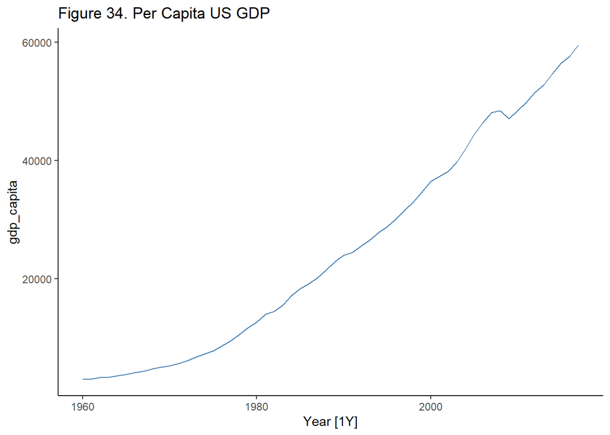

```r
usgdp<-global_economy%>%
  filter(Country %in% 'United States')%>%
  mutate(gdp_capita = GDP/Population)%>%
  select(Year, gdp_capita)

usgdp%>%
  autoplot(color='steelblue')+
  labs(title = 'Figure 34. Per Capita US GDP')+
  theme_classic()
```

```r
lambda_gdp<-usgdp%>%
  features(gdp_capita, features=guerrero)%>%
  pull(lambda_guerrero)
```

**Fit a suitable ARIMA model to the transformed data using ARIMA();**

*With lambda transformed per/capita GDP data, an ARIMA(1,1,0) model is a suitable place to start.*

```r
# identify potential model

gdp.fit<-usgdp %>%
  model(ARIMA(box_cox(gdp_capita, lambda_gdp)))

report(gdp.fit)
```

```
## Series: gdp_capita
## Model: ARIMA(1,1,0) w/ drift
## Transformation: box_cox(gdp_capita, lambda_gdp)
##
## Coefficients:
##          ar1  constant
##       0.4663    1.2236
## s.e.  0.1191    0.1235
##
## sigma^2 estimated as 0.9269:  log likelihood=-77.82
## AIC=161.64   AICc=162.09   BIC=167.77
```

```r
gdp110.drift<-usgdp%>%
  model(gdp110 = ARIMA(box_cox(gdp_capita, lambda_gdp) ~ 1 + pdq(1,1,0))) # forecast package nomenclature
```

**Try some other plausible models by experimenting with the orders chosen;**

```r
# select model from set of options

options<-usgdp%>%
  model(gdp110 = ARIMA(box_cox(gdp_capita, lambda_gdp) ~ 1 + pdq(1,1,0)),
        gdp011 = ARIMA(box_cox(gdp_capita, lambda_gdp) ~ 1 + pdq(0,1,1)),
        gdp022 =ARIMA(gdp_capita ~ 1+pdq(0,2,2)),  # untransformed, twice differenced based on auto.arima()
        stepwise=ARIMA(box_cox(gdp_capita, lambda_gdp)),
        search=ARIMA(box_cox(gdp_capita, lambda_gdp), stepwise=FALSE))


# Review diagnostics

report(options)
```

| .model | sigma2 | log_lik | AIC | AICc | BIC | ar_roots | ma_roots |
| --- | --- | --- | --- | --- | --- | --- | --- |
| gdp110 | 9.269160e-01 | -77.81952 | 161.6390 | 162.0919 | 167.7682 |  |  |
| gdp011 | 9.589571e-01 | -78.76163 | 163.5233 | 163.9761 | 169.6524 |  |  |
| gdp022 | 2.582216e+05 | -428.61862 | 865.2372 | 866.0215 | 873.3386 |  |  |
| stepwise | 9.269160e-01 | -77.81952 | 161.6390 | 162.0919 | 167.7682 |  |  |
| search | 9.269160e-01 | -77.81952 | 161.6390 | 162.0919 | 167.7682 |  |  |

**Choose what you think is the best model and check the residual diagnostics;**

*ARIMA(1,1,0) results on the lambda transformed data are identical to those calculated by search and stepwise models. Diagnostics for the former indicate white noise and no remaining autocorrelation.*

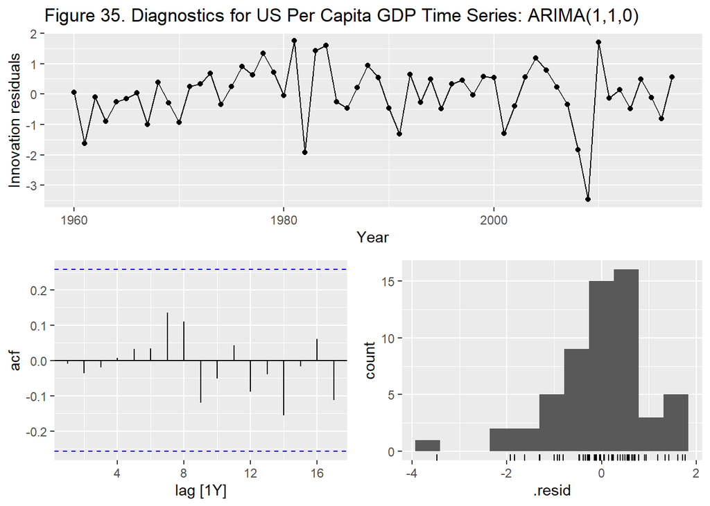

```r
# plot model diagnostics

options%>%
  select(gdp110)%>%
  gg_tsresiduals()+
  labs(title='Figure 35. Diagnostics for US Per Capita GDP Time Series: ARIMA(1,1,0)')
```

**Produce forecasts of your fitted model. Do the forecasts look reasonable?**

*Yes, the forecast looks reasonable.*

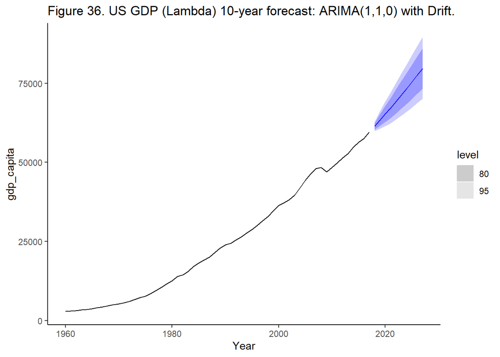

```r
gdp110.drift%>%
  forecast(h = 10) %>%
  autoplot(usgdp) +
  labs(title = 'Figure 36. US GDP (Lambda) 10-year forecast: ARIMA(1,1,0) with Drift.')+
  theme_classic()
```

**Compare the results with what you would obtain using ETS() (with no transformation).**

*This model will not include a Box-Cox transformation but GDP will be reported on a per-capita basis. We will apply a non-seasonal ETS (AAN) model and forecast for 10 year period.*

*Results of cross-validation (Table 6: see RMSE and MAPE) indicate that the ARIMA model produces a better fit than the ETS model.*

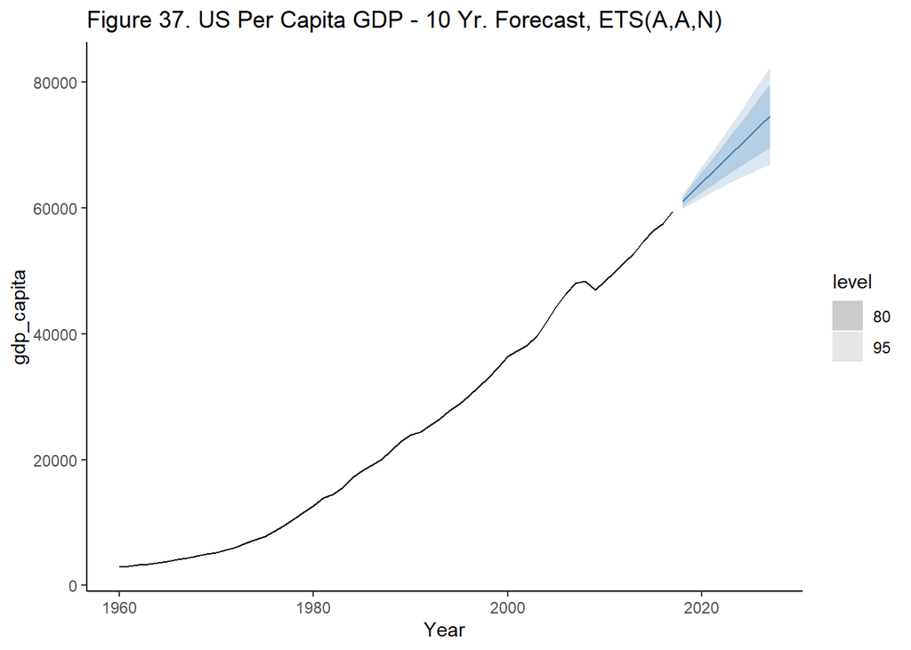

```r
#build ETS model

gdp.ets<-usgdp%>%
  model(ETS(gdp_capita ~error('A')+trend('A')+season('N')))

#build forecast

gdp.fc<-gdp.ets%>%
  forecast(h=10)

#plot forecast

gdp.fc%>%
  autoplot(usgdp, color='steelblue')+
  labs(title='Figure 37. US Per Capita GDP - 10 Yr. Forecast, ETS(A,A,N)')+
  theme_classic()
```

```r
# compare models using cross-validation

usgdp %>%
  slice(-n()) %>%
  stretch_tsibble(.init = 10) %>%
  model(
    ETS(gdp_capita ~error('A')+trend('A')+season('N')),
    ARIMA(box_cox(gdp_capita, lambda_gdp) ~ 1 + pdq(1,1,0))
  ) %>%
  forecast(h = 10) %>%
  accuracy(usgdp) %>%
  select(.model, RMSE:MAPE)%>%
  flextable()%>%
  set_caption('Table 6. Comparing Model Fit for US Per Capita GDP: ETS (AAN) vs. ARIMA(1,1,0)')
```

Table 6. Comparing Model Fit for US Per Capita GDP: ETS (AAN) vs. ARIMA(1,1,0)

| .model | RMSE | MAE | MPE | MAPE |
| --- | --- | --- | --- | --- |
| ARIMA(box_cox(gdp_capita, lambda_gdp) ~ 1 + pdq(1, 1, 0)) | 2,314.872 | 1,581.714 | 2.611373 | 6.323990 |
| ETS(gdp_capita ~ error("A") + trend("A") + season("N")) | 3,183.519 | 1,955.823 | 3.568634 | 6.859533 |